# Adding a new variable to the Dictionary

Hence, when selecting variables, attention should be paid to the time frequency data is collected at to only choose variables available with monthly or quarterly data accounts. Unfortunately, it is not possible to filter on eurostat for variables based on time frequency. However, usually, if not indicated otherwise, data is collected on an annual basis. As the images below show, when data is collected on monthly or quarterly basis, this is indicated in the name of the category the variables are stored in or the variable name itself:

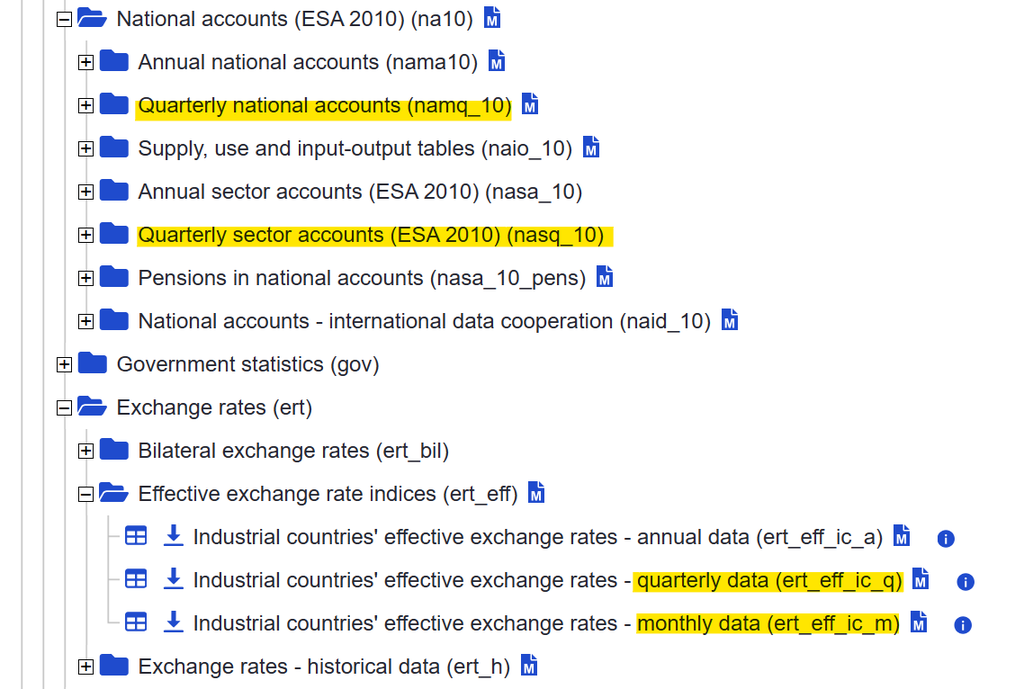

Indication of quarterly or monthly data on eurostat

Another option to find monthly, or quarterly data would be to search by keywords using, for example, “energy” and “monthly”, in the search bar on eurostat to find variables with monthly data on energy. However, the eurostat search function will only find variables, if any exist, with the exact keywords in the name that were used in the search:

[figure not shown]

searching for more specific variables on eurostat

## Preperations in R before creating the model

Before starting to actually create and run the model, make sure to install and load all relevant packages, as well as the latest version of the aggregate model.

```r
library(aggregate.model)
library(dplyr)
library(eurostat)
```

```r
library(ggplot2)
library(tidyverse)
library(kableExtra)
library(ggtext)
library(here)
library(modelsummary)
```

# Detailed model set up and running - example of a small environmental model

## Setting up the dictionary

After the conceptual work and selection of variables to be used in the model, a dictionary must be created for all variables that are not yet contained in the original dictionary that comes with the aggregate model package. Make sure to double check whether variables selected for the model to be created might not already exist in the initial dictionary.

Detailed instructions on how to add variables to the existing dictionary can be found in the [vignette “Adding a new variable to the Dictionary”](https://moritzschwarz.org/aggregate.model/articles/new_variable_to_dict.html).

The example below shows the setting up of the directory for a small rudimentary model on emissions in Austria.

```r
dict %>%
  #This is an example of a variable added from Edgar:
  bind_rows(tibble(
    model_varname = "N2O_soils", #choose a name for the variable that is unique
    full_name = "Direct N2O Emissions from managed soils", #Enter the full name/describe the variable
    database  = "edgar", #specify the data source
    dataset_id = "https://jeodpp.jrc.ec.europa.eu/ftp/jrc-opendata/EDGAR/datasets/v80_FT2022_GHG/EDGAR_N2O_m_1970_2022b.zip", #include the link to the data set
    freq = "m", #indicate the time frequency (can be m for monthly or q for quarterly)
    ipcc_sector = "3.C.4", #for Edgar variables, specify the ipcc_sector information (to be found in the excel data file the variable is contained in)
    geo = "AT" )) %>% #set the geographical region for the model, add a pipe operator to add multiple variables to the dictionary at once
  #This is an example of a variable added from Eurostat:
  bind_rows(tibble(
    model_varname = "Price_agrpro",
    full_name = "Price indices of agricultural products, output",
    database  = "eurostat", #define database as eurostat
    variable_code = "140000", #add the variable code (this specifies which details the variable should represent)
    dataset_id = "apri_pi20_outq", #add the dataset ID
    var_col = "product", #add the column name the variable code specification was chosen from
    freq = "q",
    geo = "AT",
    unit = "I20", #if given, define the unit
    s_adj = "NSA", #chose between seasonally adjusted or unadjusted data (if given)
    nace_r2 = "B-D")) %>% #define the nace_r2 sector specification, if applicable
  bind_rows(tibble(
    model_varname = "Price_animpro",
    full_name = "Price indices of agricultural products - Agricultural goods output",
    database  = "eurostat",
    variable_code = "140000",
    dataset_id = "apri_pi15_outq",
    var_col = "product",
    freq = "q",
    geo = "AT",
    unit = "I15",
    p_adj = "NI")) %>%
  bind_rows(tibble(
    model_varname = "ind_N2O_mm",
    full_name = "Indirect N2O Emissions from manure management",
    database  = "edgar",
    ipcc_sector = "3.C.6",
    dataset_id = "https://jeodpp.jrc.ec.europa.eu/ftp/jrc-opendata/EDGAR/datasets/v80_FT2022_GHG/EDGAR_N2O_m_1970_2022b.zip",
    freq = "m",
    geo = "AT")) %>%
  bind_rows(tibble(
    model_varname = "Flights",
    full_name = "National air passenger transport by reporting country",
    database  = "eurostat",
    variable_code = "CAF_PAS",
    dataset_id = "avia_panc",
    var_col = "tra_meas",
    freq = "m",
    geo = "AT",
    unit = "FLIGHT")) %>%
  bind_rows(tibble(
    model_varname = "Prod_Constr_Manu",
    full_name = "Production in Construction",
    database  = "eurostat",
    variable_code = "PROD",
    dataset_id = "sts_copr_m",
    var_col = "indic_bt",
    freq = "m",
    geo = "AT",
    unit = "I21",
    s_adj = "NSA",
    nace_r2 = "B-D_F")) %>%
  bind_rows(tibble(
    model_varname = "CO2_aviation",
    full_name = "CO2 (fossil) emissions from Civil Aviation",
    database  = "edgar",
    ipcc_sector = "1.A.3.a",
    dataset_id = "https://jeodpp.jrc.ec.europa.eu/ftp/jrc-opendata/EDGAR/datasets/v80_FT2022_GHG/IEA_EDGAR_CO2_m_1970_2022b.zip",
    freq = "m",
    geo = "AT")) %>%
  bind_rows(tibble(
    model_varname = "CO2_roads",
    full_name = "CO2 (bio) emissions from Road",
    database  = "edgar",
    ipcc_sector = "1.A.3.b_noRES",
    dataset_id = "https://jeodpp.jrc.ec.europa.eu/ftp/jrc-opendata/EDGAR/datasets/v80_FT2022_GHG/IEA_EDGAR_CO2_m_1970_2022b.zip",
    freq = "m",
    geo = "AT")) %>%
  bind_rows(tibble(
    model_varname = "CO2_Manufactoring",
    full_name = "CO2 (fossil) emissions from Manufacturing Industries and Construction",
    database  = "edgar",
    ipcc_sector = "1.A.2",
    dataset_id = "https://jeodpp.jrc.ec.europa.eu/ftp/jrc-opendata/EDGAR/datasets/v80_FT2022_GHG/IEA_EDGAR_CO2_m_1970_2022b.zip",
    freq = "m",
    geo = "AT")) %>%
  bind_rows(tibble(
    model_varname = "CO2_Residential",
    full_name = "CO2 (fossil) emissions from Residential and other sectors",
    database  = "edgar",
    ipcc_sector = "1.A.4",
    dataset_id = "https://jeodpp.jrc.ec.europa.eu/ftp/jrc-opendata/EDGAR/datasets/v80_FT2022_GHG/IEA_EDGAR_CO2_m_1970_2022b.zip",
    freq = "m",
    geo = "AT")) %>%
  bind_rows(tibble(
    model_varname = "Prod_Constr_Build",
    full_name = "Production in Construction",
    database  = "eurostat",
    variable_code = "PROD",
    dataset_id = "sts_copr_m",
    var_col = "indic_bt",
    freq = "m",
    geo = "AT",
    unit = "I21",
    s_adj = "NSA",
    nace_r2 = "F41")) %>%
  bind_rows(tibble(
    model_varname = "Lab_In_Constr",
    full_name = "Labour input in construction",
    database  = "eurostat",
    variable_code = "EMPL",
    dataset_id = "sts_colb_m",
    var_col = "indic_bt",
    freq = "m",
    geo = "AT",
    unit = "I21",
    s_adj = "NSA",
    nace_r2 = "F")) %>%
  bind_rows(tibble(
    model_varname = "Lab_In_Indus",
    full_name = "Labour input in industry",
    database  = "eurostat",
    variable_code = "EMPL",
    dataset_id = "sts_inlb_m",
    var_col = "indic_bt",
    freq = "m",
    geo = "AT",
    unit = "I21",
    s_adj = "NSA",
    nace_r2 = "B-E36")) %>%
  bind_rows(tibble(
    model_varname = "Elect_cons",
    full_name = "Consumption of electricity - GWh",
    database  = "eurostat",
    variable_code = "IS-CEL-GWH",
    dataset_id = "ei_isen_m",
    var_col = "indic",
    freq = "m",
    geo = "AT",
    unit = "NA",
    s_adj = "NSA",
    nace_r2 = "B-D")) %>%
  bind_rows(tibble(
    model_varname = "Animal_imp",
    full_name = "Total imports of live animals",
    database  = "eurostat",
    variable_code = "SL",
    dataset_id = "apro_mt_pheadm",
    var_col = "meatitem",
    freq = "m",
    geo = "AT",
    unit = "THS_T",
    s_adj = "NSA",
    nace_r2 = "B-D",
    meat = "B1000")) %>%
  bind_rows(tibble(
    model_varname = "GDP_new",
    full_name = "GDP and main aggregates - international data cooperation quarterly data",
    database  = "eurostat",
    variable_code = "B1GQ",
    dataset_id = "naidq_10_gdp",
    var_col = "na_item",
    freq = "q",
    geo = "AT",
    unit = "CP_MNAC",
    s_adj = "NSA",
    nace_r2 = "B-D")) -> environment_dict #give your new dictionary an original name
```

```r
reactable::reactable(environment_dict, searchable = TRUE, defaultPageSize = 10)
```

| model_varname | full_name | database | variable_code | dataset_id | var_col | freq | geo | unit | s_adj | nace_r2 | ipcc_sector | cpa2_1 | siec | p_adj | meat |
| --- | --- | --- | --- | --- | --- | --- | --- | --- | --- | --- | --- | --- | --- | --- | --- |
| TOTS | Total Supply | NA | TOTS | NA | NA | NA | NA | NA | NA | NA | NA | NA | NA | NA | NA |
| GDP | Gross domestic product at market prices | eurostat | B1GQ | namq_10_gdp | na_item | q | AT | CLV05_MEUR | SCA | NA | NA | NA | NA | NA | NA |
| GValueAdd | Value added, gross | eurostat | B1G | namq_10_a10 | na_item | q | AT | CLV05_MEUR | SCA | TOTAL | NA | NA | NA | NA | NA |
| Export | Exports of goods and services | eurostat | P6 | namq_10_gdp | na_item | q | AT | CLV05_MEUR | SCA | NA | NA | NA | NA | NA | NA |
| Import | Imports of goods and services | eurostat | P7 | namq_10_gdp | na_item | q | AT | CLV05_MEUR | SCA | NA | NA | NA | NA | NA | NA |
| GCapitalForm | Gross capital formation | eurostat | P5G | namq_10_gdp | na_item | q | AT | CLV05_MEUR | SCA | NA | NA | NA | NA | NA | NA |
| FinConsExp | Final consumption expenditure | eurostat | P3 | namq_10_gdp | na_item | q | AT | CLV05_MEUR | SCA | NA | NA | NA | NA | NA | NA |
| FinConsExpGov | Final consumption expenditure of general government | eurostat | P3_S13 | namq_10_gdp | na_item | q | AT | CLV05_MEUR | SCA | NA | NA | NA | NA | NA | NA |
| FinConsExpHH | Household and NPISH final consumption expenditure | eurostat | P31_S14_S15 | namq_10_gdp | na_item | q | AT | CLV05_MEUR | SCA | NA | NA | NA | NA | NA | NA |
| StatDiscrep | Statistical discrepancy (expenditure approach) | eurostat | YA0 | namq_10_gdp | na_item | q | AT | CP_MEUR | SCA | NA | NA | NA | NA | NA | NA |

[output cut: 46 more lines]

## Specifying the model

After the dictionary is completed, the following code should be used to specify the model by specifying which variables to use as dependent and which ones as independent variables. Again, drawing on the conceptual pre-analysis, it might be useful to draw on (scientific) reports and articles to identify which variables would best serve as independent variables for the dependent variables chosen. Based on that, the model specification will specify equations of independent variables that together will factor into the equivalent dependent variables.

In the example below, emissions from agriculture (through managed soils), transport (flight behaviour), manufacturing (industry), and housing/buildings were chosen as the four dependent variables that rudimentally make up general emissions in Austria. For each dependent variable, a set of independent variables has been selected. The following code will specify this environmental model:

$$\begin{aligned}
\text{Small Environmental Model:} & \\
\text{N2O\_soils} &= \beta_1 \cdot \text{ind\_N2O\_mm} + \beta_2
\cdot \text{Price\_animpro} + \beta_3 \cdot \text{Animal\_imp +} \\
\text{CO2\_aviation} &= \beta_4 \cdot \text{GDP\_new} + \beta_5
\cdot \text{Flights +} \\
\text{CO2\_Manufactoring} &= \beta_6 \cdot \text{Prod\_Constr\_Manu}
+ \beta_7 \cdot \text{Prod\_Constr\_Build} + \beta_8 \cdot
\text{Lab\_In\_Constr} + \beta_9 \cdot \text{Lab\_In\_Indus +} \\
\text{CO2\_Residential} &= \beta_{10} \cdot \text{Elect\_cons} +
\beta_{11} \cdot \text{HDD} + \beta_{12} \cdot \text{BuildingPermits}
\end{aligned}$$

Specifying this in R code results in the following:

```r
env_specification <- dplyr::tibble(
  type = c(
    "n",
    "n",
    "n",
    "n"
  ),
  dependent = c(
    "N2O_soils",
    "CO2_aviation",
    "CO2_Manufactoring",
    "CO2_Residential"
  ),
  independent = c(
    "ind_N2O_mm + Price_animpro + Animal_imp",
    "GDP_new + Flights",
    "Prod_Constr_Manu + Prod_Constr_Build + Lab_In_Constr +  Lab_In_Indus",
    "Elect_cons + HDD + BuildingPermits"
  )
)
env_specification
```

```
#> # A tibble: 4 × 3
#>   type  dependent         independent
#>   <chr> <chr>             <chr>
#> 1 n     N2O_soils         ind_N2O_mm + Price_animpro + Animal_imp
#> 2 n     CO2_aviation      GDP_new + Flights
#> 3 n     CO2_Manufactoring Prod_Constr_Manu + Prod_Constr_Build + Lab_In_Constr …
#> 4 n     CO2_Residential   Elect_cons + HDD + BuildingPermits
```

## Running the model

As soon as all relevant variables were added and the model has been specified, the “run model” function can be applied. This function can be further used for model diagnostics and forecasting.

Example using the small environmental model:

```r
env_model <- run_model(specification = env_specification, # make sure to edit this name according to your model
                       dictionary = environment_dict, # make sure to edit this name according to your model
                       inputdata_directory = here("small_examples/environmental_model/"), #make sure to edit this accordingly to where your model specification is stored
                       primary_source = "local",

                       # modify save_to_disk for each new country/specification
                       # this avoids having to download the same data multiple times
                       save_to_disk = here("small_examples/environmental_model/Environmental_model.xlsx"),

                       quiet = FALSE,
                       saturation.tpval = 0.001,
                       constrain.to.minimum.sample = FALSE)
```

```
#> Local files are used.
#> The following files are opened and scanned for relevant data for the model.
#> Environmental_model.xlsx
#> Note: If these include non-data files (with a likely different structure and hence likely errors), it is recommended to move all data files to a dedicated directory or to save them there using the 'save_to_disk' argument in the first place:
#>
#> You can quiet this message with quiet = TRUE.
#>
#> --- Estimation begins ---
#> Estimating N2O_soils = ind_N2O_mm + Price_animpro + Animal_imp
#> Estimating CO2_aviation = GDP_new + Flights
#> Estimating CO2_Manufactoring = Prod_Constr_Manu + Prod_Constr_Build + Lab_In_Constr + Lab_In_Indus
#> Estimating CO2_Residential = Elect_cons + HDD + BuildingPermits
```

## Model diagnostics

After the model has been run successfully in the step before, some initial diagnostics can be created to get some first insides into the model.

```r
env_model_list <- lapply(env_model$module_collection$model, gets::as.lm)
names(env_model_list) <- env_model$module_order$dependent

modelsummary::modelsummary(
  env_model_list,
  coef_omit = "iis|sis",
  gof_omit = "R",
  title = "Final models run for each sub-module for the illustrative example of Austria.",
  notes = "Impulse (IIS) and Step Indicators (SIS) are not shown individually but were activated for all models.",
  stars = TRUE
)
```

Final models run for each sub-module for the illustrative example of Austria.

|  | N2O_soils | CO2_aviation | CO2_Manufactoring | CO2_Residential |
| --- | --- | --- | --- | --- |
| mconst | 2.098*** | 0.035* | 0.105 | 6.278*** |
|  | (0.070) | (0.015) | (0.094) | (0.162) |
| ln.ind_N2O_mm | 0.636*** |  |  |  |
|  | (0.024) |  |  |  |
| ar1 |  | 0.990*** | 0.997*** |  |
|  |  | (0.005) | (0.012) |  |
| q_2 |  |  | −0.208*** |  |
|  |  |  | (0.005) |  |
| q_3 |  |  | −0.261*** |  |
|  |  |  | (0.005) |  |
| q_4 |  |  | 0.152*** |  |
|  |  |  | (0.005) |  |
| trend |  |  |  | −0.003*** |
|  |  |  |  | (0.001) |
| ln.HDD |  |  |  | 0.323*** |
|  |  |  |  | (0.022) |
| Num.Obs. | 212 | 211 | 211 | 176 |
| AIC | −1150.9 | −812.3 | −979.9 | 5.9 |
| BIC | −1110.6 | −782.2 | −946.3 | 21.7 |
| Log.Lik. | 587.454 | 415.174 | 499.927 | 2.074 |

+ p < 0.1, * p < 0.05, ** p < 0.01, *** p < 0.001  
Impulse (IIS) and Step Indicators (SIS) are not shown individually but were activated for all models.

```r
diagnostics_model(env_model) %>%
  rename(Module = module,
         `Indicator Share` = indicator_share) %>%
  kable(booktabs = TRUE, digits = 3, label = "diagnostics", caption = "Diagnostic results for each sub-module.") %>%
  kable_styling()
```

Diagnostic results for each sub-module.

| Module | AR | ARCH | IIS | SIS | n | Indicator Share |
| --- | --- | --- | --- | --- | --- | --- |
| N2O_soils | 0.000 | 0.000 | 0 | 9 | 212 | 0.042 |
| CO2_aviation | 0.527 | 0.250 | 6 | 0 | 211 | 0.028 |
| CO2_Manufactoring | 0.950 | 0.136 | 4 | 0 | 211 | 0.019 |
| CO2_Residential | 0.964 | 0.730 | 0 | 1 | 176 | 0.006 |

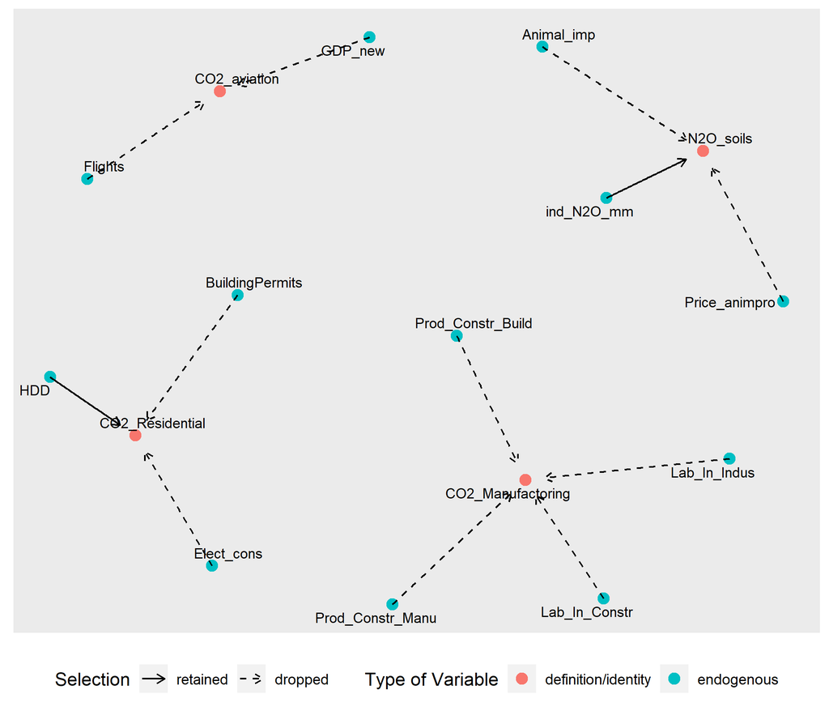

```r
# show the network graph
env_model %>%
  network()
```

## Forecasting

This step will finally do the actual forecasting intended by designing the model. The following code has specified two forecasting models but only plotted the second one of them, however, creating the same plots for the first specification should work just as well. In the end, it is a matter of choice, whether you would like missing variables to be filled through auto-regressive method (as is the case in f1), or let R chose the method of filling missing variables.

```r
# -- Forecasting ----------
f1_env <- forecast_model(env_model, exog_fill_method = "AR", plot.forecast = FALSE)
```

```
#> No exogenous values provided. Model will forecast the exogenous values with an AR4 process (incl. Q dummies, IIS and SIS w 't.pval = 0.001').
#> Alternative is exog_fill_method = 'last'.
```

```r
f2_env <- forecast_model(env_model, exog_fill_method = "auto", plot.forecast = FALSE)
```

```
#> No exogenous values provided. Model will forecast the exogenous values with the auto.arima().
```

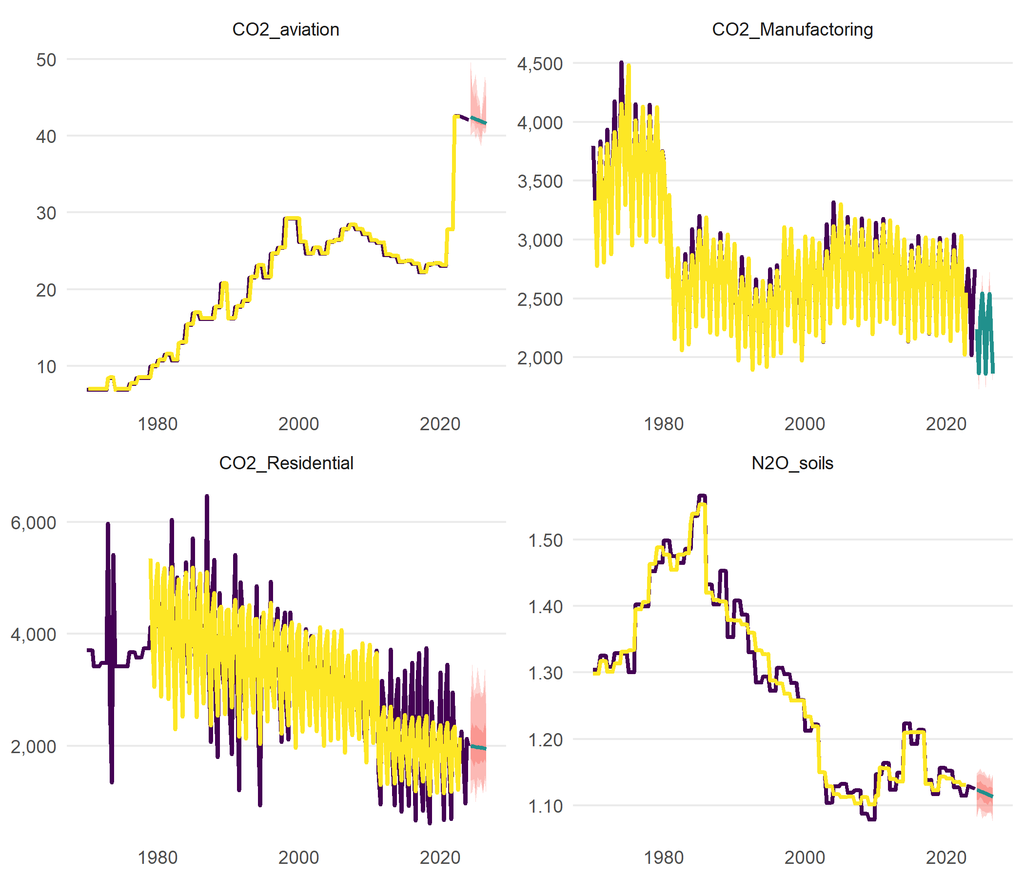

```r
plot(f2_env) +
  labs(title = "Illustrative Example for Austria", subtitle = "Showing the <span style = color:#440154FF>Observed</span>, <span style = color:#FDE725FF>Fitted</span> and <span style = color:#21908CFF>Forecasted</span> Values.") +
  theme(plot.subtitle = element_markdown()) -> p
```

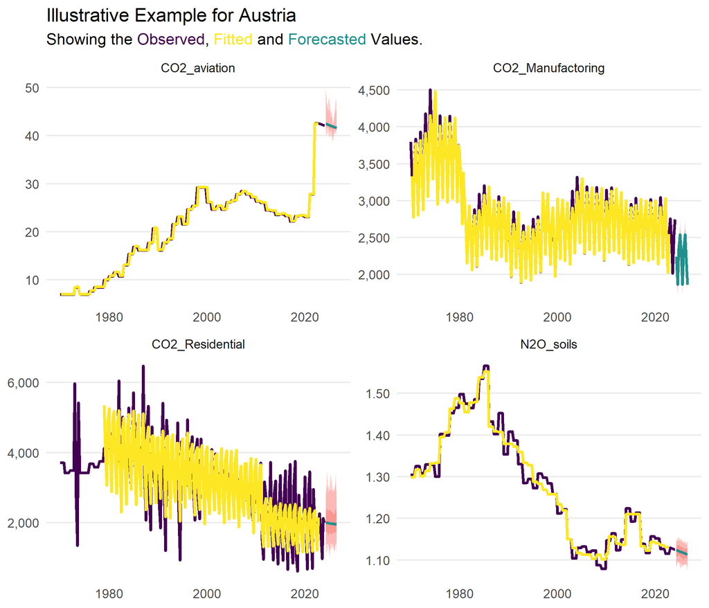

```r
p
```

And now also showing the exogenous variables:

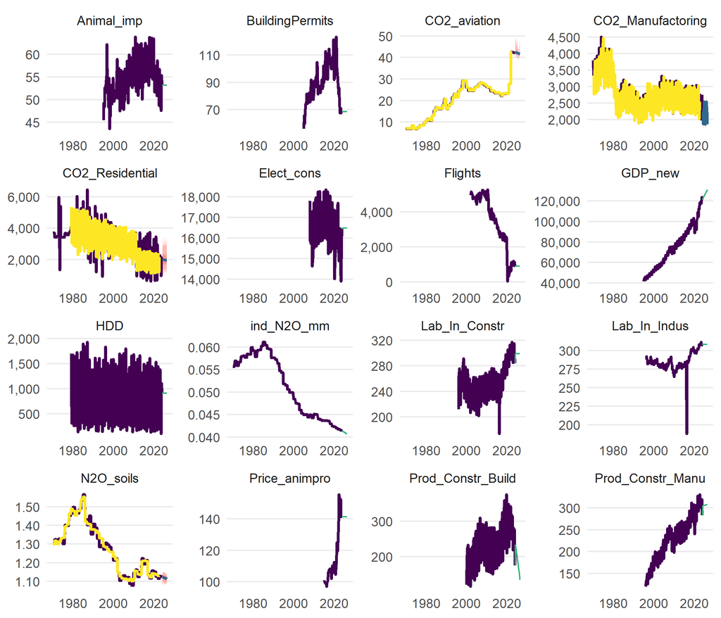

```r
plot(f2_env, exclude.exogenous = FALSE) +
  labs(title = "Illustrative Example for Austria",
       subtitle = "Showing the <span style = color:#440154FF>Observed</span>, <span style = color:#FDE725FF>Fitted</span> and <span style = color:#21908CFF>Forecasted</span> Values incl. Exogenous Variables.") +
  theme(plot.subtitle = element_markdown()) -> p
```

```r
p
```

```
#> `geom_line()`: Each group consists of only one observation.
#> ℹ Do you need to adjust the group aesthetic?
#> `geom_line()`: Each group consists of only one observation.
#> ℹ Do you need to adjust the group aesthetic?
#> `geom_line()`: Each group consists of only one observation.
#> ℹ Do you need to adjust the group aesthetic?
#> `geom_line()`: Each group consists of only one observation.
#> ℹ Do you need to adjust the group aesthetic?
```

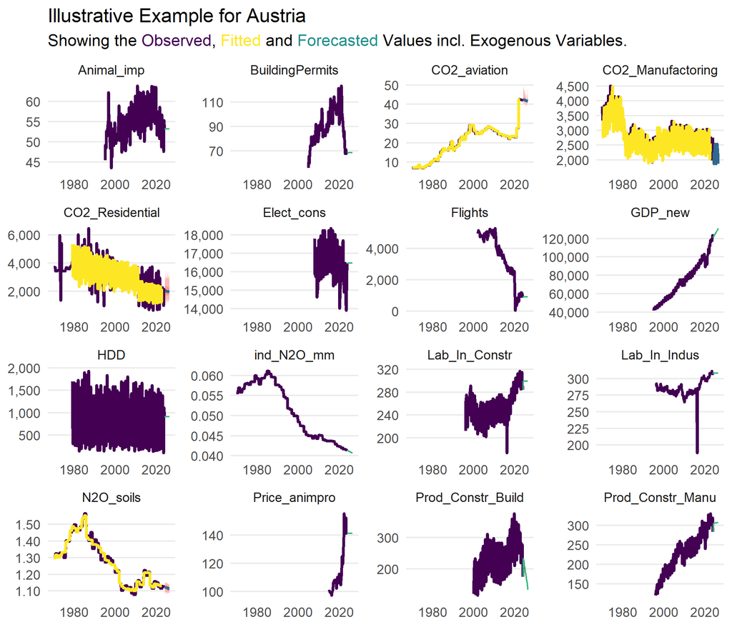

## Insample Forecasting

```r
# Insample Forecasting ----------------------------------------------------
# Here we use hind-casts to check the validity of our model
# this takes quite a bit of time, so make sure to do this wisely (check everything before)
# then perhaps try to only use .95 for the first run
# then extend to e.g. .9 or .8 to check if the model really works

f2_insample_env <- forecast_insample(env_model, sample_share = .9, exog_fill_method = "auto")
```

```
#> [1] "Model Run 1 up to 2018-10-01"
#> [1] "Model Run 2 up to 2019-01-01"
#> [1] "Model Run 3 up to 2019-04-01"
#> [1] "Model Run 4 up to 2019-07-01"
#> [1] "Model Run 5 up to 2019-10-01"
#> [1] "Model Run 6 up to 2020-01-01"
#> [1] "Model Run 7 up to 2020-04-01"
#> [1] "Model Run 8 up to 2020-07-01"
#> [1] "Model Run 9 up to 2020-10-01"
#> [1] "Model Run 10 up to 2021-01-01"
#> [1] "Model Run 11 up to 2021-04-01"
#> [1] "Model Run 12 up to 2021-07-01"
#> [1] "Model Run 13 up to 2021-10-01"
#> [1] "Model Run 14 up to 2022-01-01"
#> [1] "Model Run 15 up to 2022-04-01"
```

[output cut: 28 more lines]

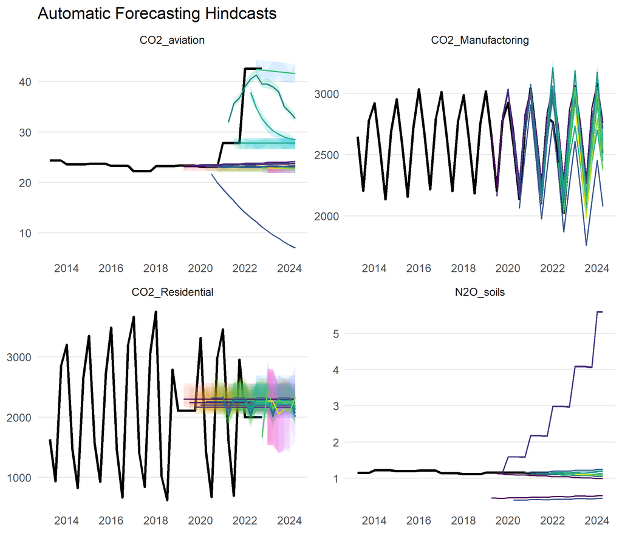

[figure not shown]

```r
# you can also change the exog_fill_method to e.g. "AR" or "last"

f2_insample_env$plot
```

# Detailed model set up and running - example of a small economic model (inflation)

Let’s explore how to use the aggregate model on a different example, in this case for forecasting inflation.

## Setting up the dictionary

Just as in the example of the small environmental model, after the conceptual work and selection of variables to be used in the model, a dictionary must be created for all variables that are not yet contained in the original dictionary that comes with the aggregate model package.

The example below shows the setting up of the directory for a small rudimentary model on inflation in Austria. The following equation shows the type of model to be set up and run in R:
$$\begin{aligned}
\text{Small Inflation Model:} & \\
\text{PPI} &= \beta_1 \cdot \text{FinConsExpHH} + \beta_2 \cdot
\text{LabCostManuf} + \beta_3 \cdot \text{Export} + \beta_4 \cdot
\text{TurnIndus +} \\
\text{GDP\_deflator} &= \beta_5 \cdot \text{HICP} + \beta_6 \cdot
\text{GDP} + \beta_7 \cdot \text{Import} + \beta_8 \cdot
\text{Exchange\_rates +} \\
\text{Unemployment} &= \beta_9 \cdot \text{LabCost\_ICS} +
\beta_{10} \cdot \text{ParttimeEmploy} + \beta_{11} \cdot
\text{Compensation}
\end{aligned}$$
For clarification, the dependent variable “PPI” refers to the Producer Price Index in terms of output prices of the domestic market. Further elaborations and clarifications concerning the variable names and meanings of the independent variables can be taken from their specifications in their dictionary entries below. Because some variables contained in the small inflation model were not yet contained in the default dictionary of the package, they have to be added to the dictionary, creating a new sub-dictionary for this specific model.

```r
dict %>%
  bind_rows(tibble(
    model_varname = "TurnIndus",
    full_name = "Turnover in industry, domestic market - monthly data",
    database  = "eurostat",
    variable_code = "TOVD",
    dataset_id = "sts_intvd_m",
    var_col = "indic_bt",
    freq = "m",
    geo = "AT",
    unit = "I21",
    s_adj = "NSA",
    nace_r2 = "B_C")) %>%
  bind_rows(tibble(
    model_varname = "PPI",
    full_name = "Output prices of the domestic market index (Producer price index) (NSA)",
    database  = "eurostat",
    variable_code = "IS-PPI",
    dataset_id = "ei_isir_m",
    var_col = "indic",
    freq = "m",
    geo = "AT",
    unit = "RT1",
    s_adj = "NSA",
    nace_r2 = "B-E36")) %>%
  bind_rows(tibble(
    model_varname = "Unemployment",
    full_name = "Unemployment",
    database  = "eurostat",
    variable_code = "T",
    dataset_id = "lfsq_urgan",
    var_col = "sex",
    age = "Y20-64",
    citizen = "TOTAL",
    freq = "q",
    geo = "AT",
    unit = "PC",
    s_adj = "NSA")) %>%
  bind_rows(tibble(
    model_varname = "ParttimeEmploy",
    full_name = "Part-time employment and temporary contracts",
    database  = "eurostat",
    variable_code = "T",
    dataset_id = "lfsi_pt_q",
    var_col = "sex",
    age = "Y20-64",
    wstatus = "EMP_PT",
    freq = "q",
    geo = "AT",
    unit = "PC_EMP",
    s_adj = "NSA",
    nace_r2 = " ")) %>%
  bind_rows(tibble(
    model_varname = "Compensation",
    full_name = "Compensation of employees",
    database  = "eurostat",
    variable_code = "D1",
    dataset_id = "tipslm14",
    var_col = "na_item",
    freq = "q",
    geo = "AT",
    unit = "CP_MNAC",
    s_adj = "NSA",
    nace_r2 = " ")) %>%
  bind_rows(tibble(
    model_varname = "Exchange_rates",
    full_name = "Nominal effective exchange rate - 42 trading partners (industrial countries)",
    database  = "eurostat",
    variable_code = "NEER_IC42",
    dataset_id = "ert_eff_ic_q",
    var_col = "exch_rt",
    freq = "q",
    geo = "AT",
    unit = "I15",
    s_adj = "NSA")) %>%

  # bind_rows(tibble(
  #   model_varname = "GDP_deflator",
  #   full_name = "GDP deflator",
  #   database  = "eurostat",
  #   variable_code = "B1GQ",
  #   dataset_id = "teina110",
  #   var_col = "na_item",
  #   freq = "q",
  #   geo = "AT",
  #   unit = "PD10_EUR",
  #   #s_adj = "NSA" # would need to be SCA
  #   s_adj = "SCA"
  #   )) %>%

  bind_rows(tibble(
    model_varname = "GDP_deflator",
    full_name = "GDP deflator",
    database  = "eurostat",
    variable_code = "B1GQ",
    dataset_id = "namq_10_gdp",
    var_col = "na_item",
    freq = "q",
    geo = "AT",
    unit = "PD10_EUR",
    s_adj = "NSA"
  )) %>%

  bind_rows(tibble(
    model_varname = "LabCost_ICS",
    full_name = "labour cost index in Industry, construction and services ",
    database  = "eurostat",
    variable_code = "LM-LCI-TOT",
    dataset_id = "ei_lmlc_q",
    var_col = "indic",
    freq = "q",
    geo = "AT",
    unit = "I20",
    s_adj = "NSA",
    nace_r2 = "B-S")) -> economic_dict
```

```r
reactable::reactable(economic_dict, searchable = TRUE, defaultPageSize = 10)
```

| model_varname | full_name | database | variable_code | dataset_id | var_col | freq | geo | unit | s_adj | nace_r2 | ipcc_sector | cpa2_1 | siec | age | citizen | wstatus |
| --- | --- | --- | --- | --- | --- | --- | --- | --- | --- | --- | --- | --- | --- | --- | --- | --- |
| TOTS | Total Supply | NA | TOTS | NA | NA | NA | NA | NA | NA | NA | NA | NA | NA | NA | NA | NA |
| GDP | Gross domestic product at market prices | eurostat | B1GQ | namq_10_gdp | na_item | q | AT | CLV05_MEUR | SCA | NA | NA | NA | NA | NA | NA | NA |
| GValueAdd | Value added, gross | eurostat | B1G | namq_10_a10 | na_item | q | AT | CLV05_MEUR | SCA | TOTAL | NA | NA | NA | NA | NA | NA |
| Export | Exports of goods and services | eurostat | P6 | namq_10_gdp | na_item | q | AT | CLV05_MEUR | SCA | NA | NA | NA | NA | NA | NA | NA |
| Import | Imports of goods and services | eurostat | P7 | namq_10_gdp | na_item | q | AT | CLV05_MEUR | SCA | NA | NA | NA | NA | NA | NA | NA |
| GCapitalForm | Gross capital formation | eurostat | P5G | namq_10_gdp | na_item | q | AT | CLV05_MEUR | SCA | NA | NA | NA | NA | NA | NA | NA |
| FinConsExp | Final consumption expenditure | eurostat | P3 | namq_10_gdp | na_item | q | AT | CLV05_MEUR | SCA | NA | NA | NA | NA | NA | NA | NA |
| FinConsExpGov | Final consumption expenditure of general government | eurostat | P3_S13 | namq_10_gdp | na_item | q | AT | CLV05_MEUR | SCA | NA | NA | NA | NA | NA | NA | NA |
| FinConsExpHH | Household and NPISH final consumption expenditure | eurostat | P31_S14_S15 | namq_10_gdp | na_item | q | AT | CLV05_MEUR | SCA | NA | NA | NA | NA | NA | NA | NA |
| StatDiscrep | Statistical discrepancy (expenditure approach) | eurostat | YA0 | namq_10_gdp | na_item | q | AT | CP_MEUR | SCA | NA | NA | NA | NA | NA | NA | NA |

[output cut: 38 more lines]

## Specifying the model

Having completed this dictionary, the model outlined above, has to be specified in R:

```r
infl_specification <- dplyr::tibble(
  type = c(
    "n",
    "n",
    "n"
  ),
  dependent = c(
    "PPI",
    "GDP_deflator",
    "Unemployment"
  ),
  independent = c(
    "FinConsExpHH + LabCostManuf + Export + TurnIndus",
    "HICP + GDP + Import + Exchange_rates",
    "LabCost_ICS + ParttimeEmploy + Compensation"
  )
)
infl_specification
```

```
#> # A tibble: 3 × 3
#>   type  dependent    independent
#>   <chr> <chr>        <chr>
#> 1 n     PPI          FinConsExpHH + LabCostManuf + Export + TurnIndus
#> 2 n     GDP_deflator HICP + GDP + Import + Exchange_rates
#> 3 n     Unemployment LabCost_ICS + ParttimeEmploy + Compensation
```

## Running the model

As soon as all relevant variables were added and the model has been specified, the “run model” function can be applied. This function can be further used for model diagnostics and forecasting.

```r
infl_model <- run_model(specification = infl_specification, # make sure to edit this name according to your model
                        dictionary = economic_dict, # make sure to edit this name according to your model
                        inputdata_directory = here("small_examples/economic_models/"), #make sure to edit this accordingly to where your model specification is stored
                        primary_source = "local",
                        use_logs = "none",

                        # modify save_to_disk for each new country/specification
                        # this avoids having to download the same data multiple times
                        save_to_disk = here("small_examples/economic_models/inflation_model.xlsx"),

                        quiet = FALSE,
                        saturation.tpval = 0.001,
                        constrain.to.minimum.sample = FALSE)
```

```
#> Local files are used.
#> The following files are opened and scanned for relevant data for the model.
#> inflation_model.xlsx
#> Note: If these include non-data files (with a likely different structure and hence likely errors), it is recommended to move all data files to a dedicated directory or to save them there using the 'save_to_disk' argument in the first place:
#>
#> You can quiet this message with quiet = TRUE.
#>
#> --- Estimation begins ---
#> Estimating PPI = FinConsExpHH + LabCostManuf + Export + TurnIndus
#> Warning: There was 1 warning in `dplyr::mutate()`.
#> ℹ In argument: `dplyr::across(-"time", list(ln = log), .names =
#>   "{.fn}.{.col}")`.
#> Caused by warning:
#> ! NaNs produced
#> Estimating GDP_deflator = HICP + GDP + Import + Exchange_rates
#> Estimating Unemployment = LabCost_ICS + ParttimeEmploy + Compensation
```

## Model diagnostics

After the model has been run successfully in the step before, some initial diagnostics can be created to get some first insides into the model.

```r
infl_model_list <- lapply(infl_model$module_collection$model, gets::as.lm)
names(infl_model_list) <- infl_model$module_order$dependent

modelsummary::modelsummary(
  infl_model_list,
  coef_omit = "iis|sis",
  gof_omit = "R",
  title = "Final models run for each sub-module for the illustrative example of Austria.",
  notes = "Impulse (IIS) and Step Indicators (SIS) are not shown individually but were activated for all models.",
  stars = TRUE
)
```

Final models run for each sub-module for the illustrative example of Austria.

|  | PPI | GDP_deflator | Unemployment |
| --- | --- | --- | --- |
| mconst | −22.097*** | 0.708 | 0.167 |
|  | (3.517) | (1.795) | (0.551) |
| ar1 | −0.016 | 0.309*** | 0.622*** |
|  | (0.063) | (0.071) | (0.063) |
| trend | −0.093*** |  |  |
|  | (0.014) |  |  |
| TurnIndus | 0.065*** |  |  |
|  | (0.011) |  |  |
| L1.FinConsExpHH | 0.001*** |  |  |
|  | (0.000) |  |  |
| L1.TurnIndus | −0.078*** |  |  |
|  | (0.012) |  |  |
| q_2 | −4.559*** | 0.992*** | 0.492* |
|  | (0.648) | (0.174) | (0.190) |
| q_3 | −2.625*** | 0.543*** | −0.685*** |
|  | (0.454) | (0.125) | (0.196) |
| q_4 | −3.342*** | 0.820*** |  |
|  | (0.472) | (0.170) |  |
| ar2 |  | 0.460*** |  |
|  |  | (0.061) |  |
| HICP |  | 0.201*** |  |
|  |  | (0.025) |  |
| GDP |  | 0.000*** |  |
|  |  | (0.000) |  |
| Exchange_rates |  | 0.076*** |  |
|  |  | (0.022) |  |
| L1.HICP |  | −0.129*** |  |
|  |  | (0.031) |  |
| L2.Import |  | 0.000*** |  |
|  |  | (0.000) |  |
| LabCost_ICS |  |  | 0.046* |
|  |  |  | (0.018) |
| Compensation |  |  | 0.000** |
|  |  |  | (0.000) |
| L1.LabCost_ICS |  |  | 0.082*** |
|  |  |  | (0.022) |
| L1.Compensation |  |  | 0.000* |
|  |  |  | (0.000) |
| Num.Obs. | 111 | 111 | 59 |
| AIC | 293.2 | 145.7 | 33.7 |
| BIC | 336.5 | 183.6 | 54.5 |
| Log.Lik. | −130.579 | −58.830 | −6.851 |

+ p < 0.1, * p < 0.05, ** p < 0.01, *** p < 0.001  
Impulse (IIS) and Step Indicators (SIS) are not shown individually but were activated for all models.

```r
diagnostics_model(infl_model) %>%
  rename(Module = module,
         `Indicator Share` = indicator_share) %>%
  kable(booktabs = TRUE, digits = 3, label = "diagnostics", caption = "Diagnostic results for each sub-module.") %>%
  kable_styling()
```

Diagnostic results for each sub-module.

| Module | AR | ARCH | IIS | SIS | n | Indicator Share |
| --- | --- | --- | --- | --- | --- | --- |
| PPI | 0.472 | 0.343 | 3 | 3 | 111 | 0.054 |
| GDP_deflator | 0.179 | 0.110 | 0 | 2 | 111 | 0.018 |
| Unemployment | 0.626 | 0.528 | 1 | 0 | 59 | 0.017 |

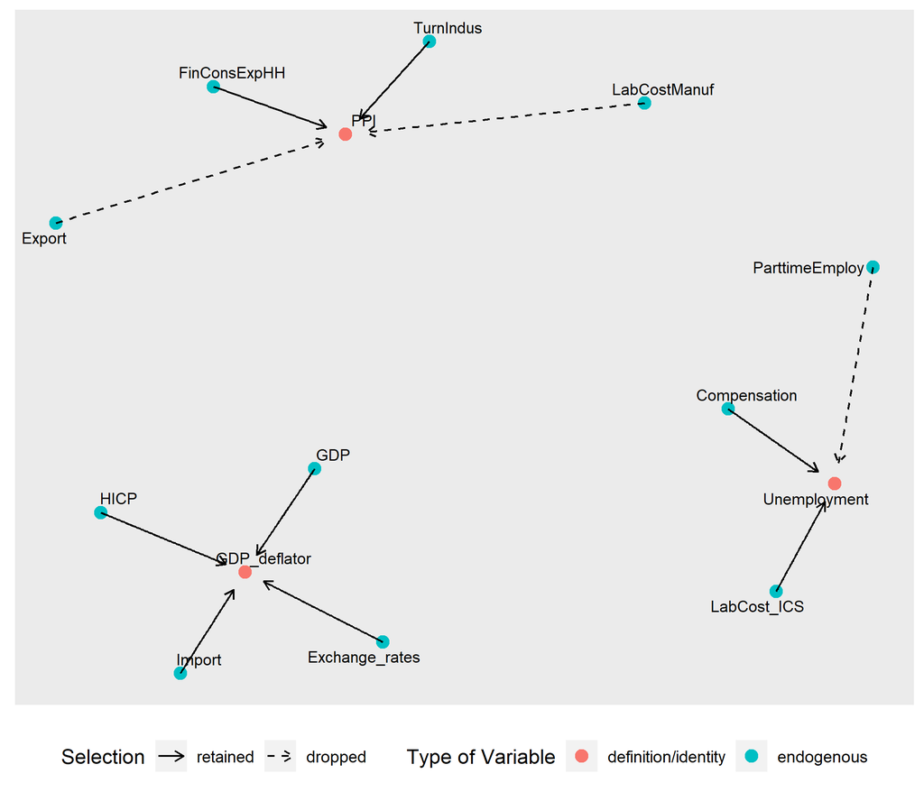

```r
# show the network graph
infl_model %>%
  network()
```

## Forecasting

This step will finally do the actual forecasting intended by designing the model. The following code has specified two forecasting models but only plotted the second one of them, however, creating the same plots for the first specification should work just as well. In the end, it is a matter of choice, whether you would like missing variables to be filled through auto-regressive method (as is the case in f1), or let R chose the method of filling missing variables.

```r
# -- Forecasting ----------
f1_infl <- forecast_model(infl_model, exog_fill_method = "AR", plot.forecast = FALSE)
```

```
#> No exogenous values provided. Model will forecast the exogenous values with an AR4 process (incl. Q dummies, IIS and SIS w 't.pval = 0.001').
#> Alternative is exog_fill_method = 'last'.
```

```r
f2_infl <- forecast_model(infl_model, exog_fill_method = "auto", plot.forecast = FALSE)
```

```
#> No exogenous values provided. Model will forecast the exogenous values with the auto.arima().
```

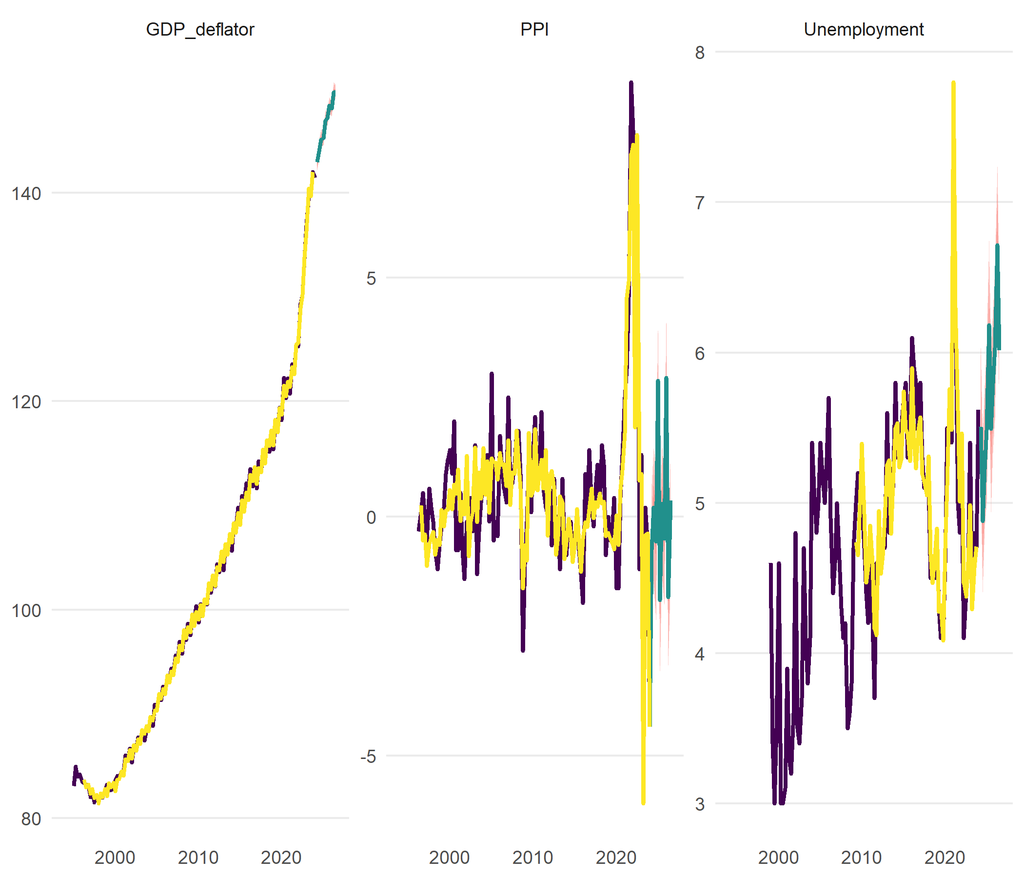

```r
plot(f2_infl) +
  labs(title = "Illustrative Example for Austria", subtitle = "Showing the <span style = color:#440154FF>Observed</span>, <span style = color:#FDE725FF>Fitted</span> and <span style = color:#21908CFF>Forecasted</span> Values.") +
  theme(plot.subtitle = element_markdown()) -> p
```

And now also showing the exogenous variables:

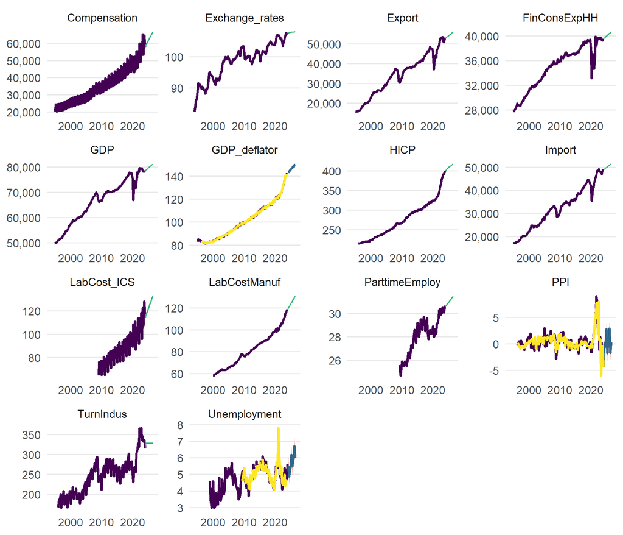

```r
plot(f2_infl, exclude.exogenous = FALSE) +
  labs(title = "Illustrative Example for Austria",
       subtitle = "Showing the <span style = color:#440154FF>Observed</span>, <span style = color:#FDE725FF>Fitted</span> and <span style = color:#21908CFF>Forecasted</span> Values incl. Exogenous Variables.") +
  theme(plot.subtitle = element_markdown()) -> p
```

```r
p
```

```
#> `geom_line()`: Each group consists of only one observation.
#> ℹ Do you need to adjust the group aesthetic?
#> `geom_line()`: Each group consists of only one observation.
#> ℹ Do you need to adjust the group aesthetic?
#> `geom_line()`: Each group consists of only one observation.
#> ℹ Do you need to adjust the group aesthetic?
```

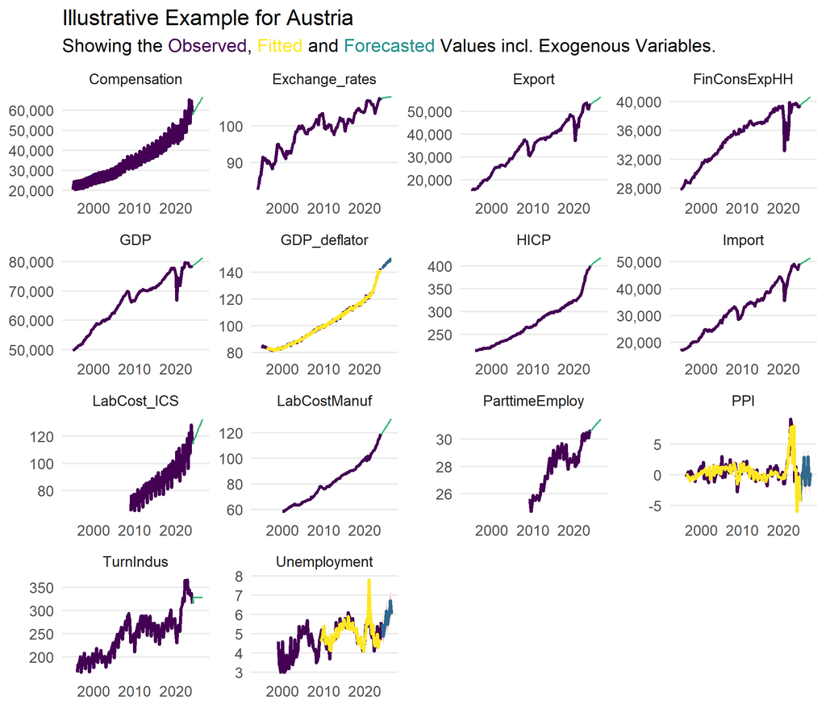

## Insample Forecasting

```r
# Insample Forecasting ----------------------------------------------------
# Here we use hind-casts to check the validity of our model
# this takes quite a bit of time, so make sure to do this wisely (check everything before)
# then perhaps try to only use .95 for the first run
# then extend to e.g. .9 or .8 to check if the model really works

f2_insample_infl <- forecast_insample(infl_model, sample_share = .97, exog_fill_method = "auto")
```

```
#> [1] "Model Run 1 up to 2023-04-01"
#> [1] "Model Run 2 up to 2023-07-01"
#> [1] "Model Run 3 up to 2023-10-01"
#> [1] "Model Run 4 up to 2024-01-01"
#> [1] "Forecast 1 from 2023-04-01 to 2024-01-01"
#> [1] "Forecast 2 from 2023-07-01 to 2024-01-01"
#> [1] "Forecast 3 from 2023-10-01 to 2024-01-01"
#> Warning: Removed 1 row containing missing values (`geom_line()`).
```

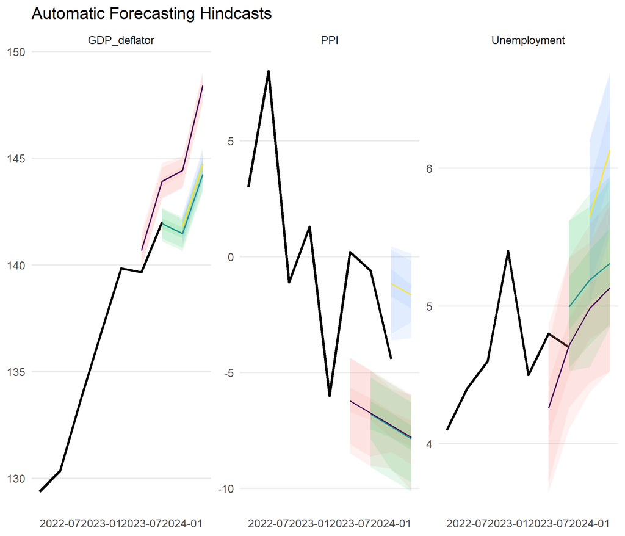

[figure not shown]

```r
# you can also change the exog_fill_method to e.g. "AR" or "last"

f2_insample_infl$plot
```

# Some last things to keep in mind:

- Make sure to edit all variable and function names according to your own model. In this case I used “infl” for the inflation model and “env” for the environment model as a prefix or suffix for specified functions or variables like “model” or “specification”. If R tells you in an error message that it does not recognize a certain function, double check, whether all functions have been renamed in the same way.
- When adding variables to the dictionary, make sure that there is enough data for your selected variable on eurostat by selecting all variable specifications chose for the variable in the data manager on eurostat and check the data in the preliminary data viewer.